# Predicting Form of Exercise from Sensor Data

Joraaver Chahal

July 18, 2015

## Abstract

The science in lifting has become very prevalent in today’s technology-driven society. However, both recreational and professionals have one thing in common when it comes to lifting weights–injuries due to bad form. Professional video recording equipment, posting form-checks on reddit, and even asking for a friend to spot the lift are all common practices, ultimately aiming to perfect one’s form. With the onset of wearables that can tell when someone’s accomplished a walking goal or remind him to get up after 20 minutes, can they also tell lifters when their form is off? This study attempts to predict when a lifter’s form is good or bad, via the data provided here: http://groupware.les.inf.puc-rio.br/har (see Weight Lifting Exercises Dataset) . In the study, the participants were asked to perform bicep curls, each in one of 5 different manners (labeled A-E). With the provided sensor data, this report details how accurately I came to predicting the form of each of the lifters using machine learning techniques.

## Data Preparation

The training and testing datasets were provided at these two links:

https://d396qusza40orc.cloudfront.net/predmachlearn/pml-training.csv https://d396qusza40orc.cloudfront.net/predmachlearn/pml-testing.csv

Simply downloading them and reading them in via `read.csv` suffices.

```
pml.training <- read.csv("Path-to-your-csv/pml-training.csv",header=T,stringsAsFactors = F,na.strings=c("NA","#DIV/0!","")))
pml.testing <- read.csv("Path-to-your-csv/pml-testing.csv",header=T,stringsAsFactors = F,na.strings=c("NA","#DIV/0!","")))
```

## Data Exploration

I like to do my work with tidy and dplyr, and provide visualizations via ggplot2, so I’ll load those now.

```r
library(tidyr)
library(dplyr)
```

```r
library(ggplot2)
```

### Data cleanup

First, a quick glance at the size of the training data frame tells me that there are a lot of predictors to deal with.

```r
dim(pml.training)
```

```
## [1] 19622   160
```

However, the first columns of the data frame are row number and username, and other qualitative stuff that I don’t see necessarily helping my analysis. Or, rather, they wouldn’t stand for how I should be predicting the class of exercised. I recognized early on that just taking `user_name` and `num_window` would suffice in getting most of the correct predictions. However, this is not utilizing the sensor data, making the project trival. Thus, I removed those columns immediately.

```r
pml.training <- pml.training[,-c(1:7)]
pml.testing <- pml.testing[,-c(1:7)]
```

Now, I went ahead and removed any columns in the training set that weren’t in the testing set and any columns and rows if any in the training set were NA’s.

```r
nonempty_cols= c()
for(i in 1:dim(pml.testing)[2]){
  if(sum(is.na(pml.testing[,i])) == 0 )
    nonempty_cols = c(nonempty_cols,colnames(pml.testing)[i])
}
nonempty_cols[length(nonempty_cols)] = "classe"
training = pml.training[,colnames(pml.training) %in% nonempty_cols]

empty_rows = c()

for(i in 1:dim(training)[1]){
    empty_rows = c(empty_rows,sum(is.na(training[i,])))
}
training = training[empty_rows == 0,]
```

This is the final distribution of classes:

```r
table(training$classe)
```

```
##
##    A    B    C    D    E
## 5580 3797 3422 3216 3607
```

## Machine Learning Techniques

I’ll load the `caret` package now.

```r
library(caret)
```

After playing around with the data for a little while, it became obvious that the more samples I used in my training set, the better. Smaller samples at around 500~600 for training/cross-validation (making the training set even smaller) only resulted in about 82% accuracy. However, sampling larger sets rose the accuracy significantly, until I hit about 98% accuracy. Nonetheless, the smaller models actually gave me a chance to plot out and see if the predictors were heading in the right direction. I used the random forest method for the learning algorithm (I would have used parallel random forest, but RStudio said the package parallel isn’t available for R 3.2.1). I also used simple k-fold cross validation with k=10, which is a generally recommended value between variance in validation and selection bias.

```r
set.seed(12323)
training$classe = factor(training$classe)
training = sample_n(training,size=6000)
trainIndex = createDataPartition(training$classe,p=0.6,list=F)
to_train = training[trainIndex,]
to_validate = training[-trainIndex,]
model = train(to_train[,-c(dim(to_train)[2])], to_train$classe,trControl=trainControl(method="cv",number=10),method="rf")
model$results
```

```
##   mtry  Accuracy     Kappa AccuracySD    KappaSD
## 1    2 0.9641874 0.9546574 0.01117157 0.01414536
## 2   27 0.9719621 0.9645078 0.01002733 0.01270933
## 3   52 0.9636372 0.9539726 0.01084966 0.01375528
```

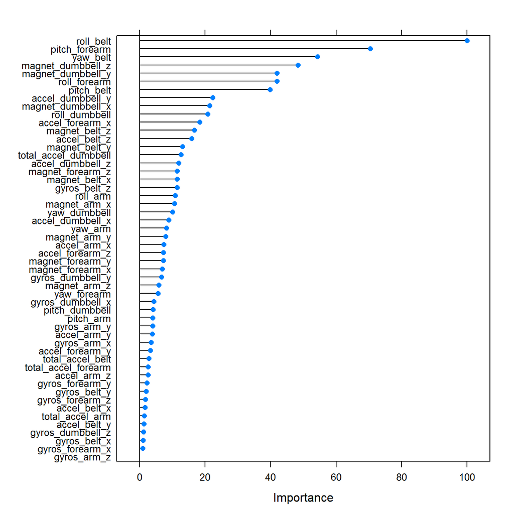

```r
plot(varImp(model))
```

I decided to go ahead with this model even though most of the predictors towards the bottom didn’t show much improvement simply because the model seemed to do a good job of fitting the validation set. Just to double check how the variables were factoring, I plotted the predictors `roll_belt` against `pitch_forearm`, with `yaw_belt`as the size, and `classe` as the color.

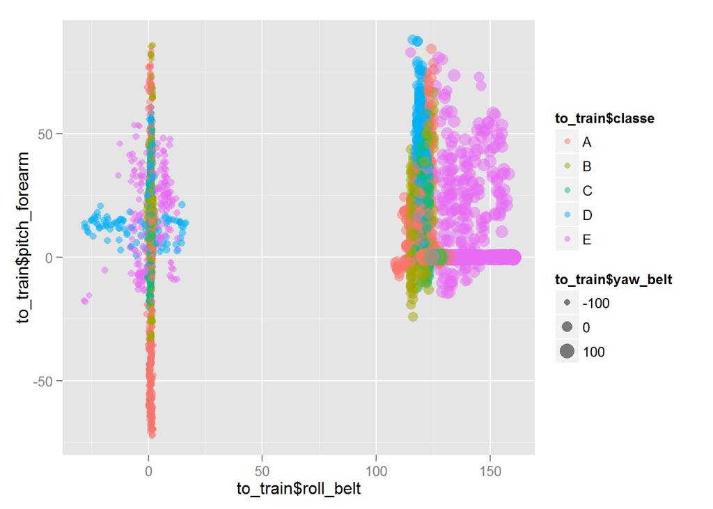

```r
qplot(to_train$roll_belt,to_train$pitch_forearm,color=to_train$classe,size=to_train$yaw_belt, alpha=I(0.5))
```

There is a very solid distinction between these sets of variables now. `roll_belt`, as the model shows, creates a great rift between the sets of variables, with `pitch_forearm` describing perhaps the left half of the data better. The third most variable, `yaw_belt`, also demonstrates a distinction between the two groups, and an especially clear difference in class E. All in all, the model seems to have done a good job, and it makes sense intuitively why these predictors would account for the most variance in the data.

The prediction below on the validation set provides the out of sample error:

```r
validation = predict(model,to_validate,"raw")
confusionMatrix(validation,to_validate$classe)
```

```
## Confusion Matrix and Statistics
##
##           Reference
## Prediction   A   B   C   D   E
##          A 677   9   0   0   0
##          B   5 427  16   1   0
##          C   2   8 403  10   1
##          D   1   2   2 387   1
##          E   1   0   0   2 442
##
## Overall Statistics
##
##                Accuracy : 0.9746
##                  95% CI : (0.9674, 0.9805)
##     No Information Rate : 0.2862
##     P-Value [Acc > NIR] : < 2.2e-16
##
##                   Kappa : 0.9678
##  Mcnemar's Test P-Value : NA
##
## Statistics by Class:
##
##                      Class: A Class: B Class: C Class: D Class: E
## Sensitivity            0.9869   0.9574   0.9572   0.9675   0.9955
## Specificity            0.9947   0.9887   0.9894   0.9970   0.9985
## Pos Pred Value         0.9869   0.9510   0.9505   0.9847   0.9933
## Neg Pred Value         0.9947   0.9902   0.9909   0.9935   0.9990
## Prevalence             0.2862   0.1861   0.1756   0.1669   0.1852
## Detection Rate         0.2824   0.1781   0.1681   0.1615   0.1844
## Detection Prevalence   0.2862   0.1873   0.1769   0.1640   0.1856
## Balanced Accuracy      0.9908   0.9731   0.9733   0.9822   0.9970
```

Finally, my predicted values for the set were as follows:

```r
to_keep = colnames(training)
to_test = pml.testing[ ,colnames(pml.testing) %in% to_keep]
prediction = predict(model,to_test,"raw")
prediction
```

```
##  [1] B A B A A E D D A A B C B A E E A D B B
## Levels: A B C D E
```